# 6.1 Reading and Writing Data in Text Format

pandas features a number of functions for reading tabular data as a DataFrame object. Table 6-1 summarizes some of them, though `read_csv` and `read_table` are likely the ones you’ll use the most

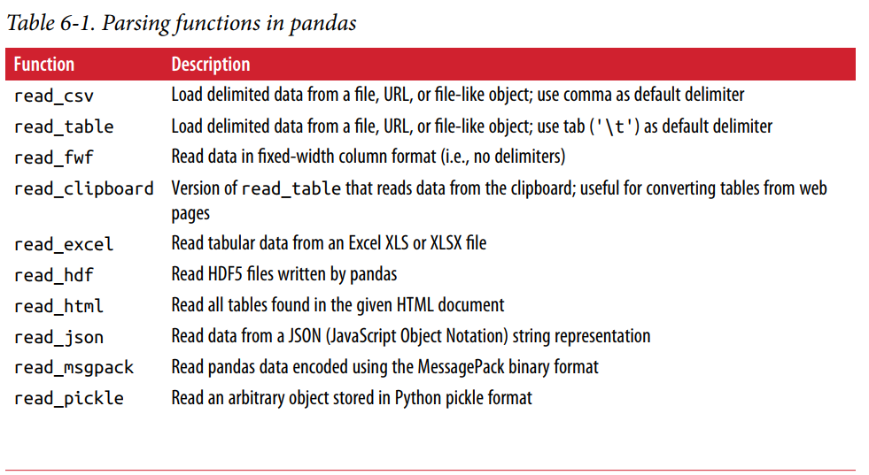

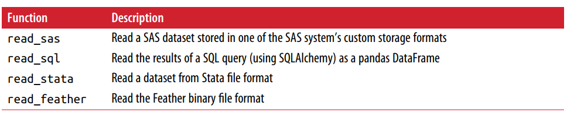

```python
import pandas as pd
import numpy as np
```

```python
!cat ../examples/ex1.csv
```

```
a,b,c,d,message
1,2,3,4,hello
5,6,7,8,world
9,10,11,12,foo
```

Since this is comma-delimited, we can use `read_csv` to read it into a DataFrame:

```python
df = pd.read_csv('../examples/ex1.csv')
df
```

|  | a | b | c | d | message |
| --- | --- | --- | --- | --- | --- |
| 0 | 1 | 2 | 3 | 4 | hello |
| 1 | 5 | 6 | 7 | 8 | world |
| 2 | 9 | 10 | 11 | 12 | foo |

We could also have used `read_table` and **specified the delimiter**:

```python
pd.read_table('../examples/ex1.csv', sep=',')
```

|  | a | b | c | d | message |
| --- | --- | --- | --- | --- | --- |
| 0 | 1 | 2 | 3 | 4 | hello |
| 1 | 5 | 6 | 7 | 8 | world |
| 2 | 9 | 10 | 11 | 12 | foo |

A file will not always have a header row. Consider this file:

```python
!cat ../examples/ex2.csv
```

```
1,2,3,4,hello
5,6,7,8,world
9,10,11,12,foo
```

To read this file, you have a couple of options.

- You can allow pandas to assign default column names
- You can specify names yourself:

```python
pd.read_csv('../examples/ex2.csv', header=None)
```

|  | 0 | 1 | 2 | 3 | 4 |
| --- | --- | --- | --- | --- | --- |
| 0 | 1 | 2 | 3 | 4 | hello |
| 1 | 5 | 6 | 7 | 8 | world |
| 2 | 9 | 10 | 11 | 12 | foo |

```python
pd.read_csv('../examples/ex2.csv', names=['a', 'b', 'c', 'd', 'message'])
```

|  | a | b | c | d | message |
| --- | --- | --- | --- | --- | --- |
| 0 | 1 | 2 | 3 | 4 | hello |
| 1 | 5 | 6 | 7 | 8 | world |
| 2 | 9 | 10 | 11 | 12 | foo |

Suppose you wanted the message column to be the index of the returned DataFrame. You can either indicate you want the column at index 4 or named 'message' using the `index_col` argument:

```python
names = ['a', 'b', 'c', 'd', 'message']
pd.read_csv('../examples/ex2.csv',names=names,  index_col='message')
```

| message | a | b | c | d |
| --- | --- | --- | --- | --- |
| hello | 1 | 2 | 3 | 4 |
| world | 5 | 6 | 7 | 8 |
| foo | 9 | 10 | 11 | 12 |

In the event that you want to form a **hierarchical index from multiple columns,** pass a list of column numbers or names:

```python
!cat ../examples/csv_mindex.csv
```

```
key1,key2,value1,value2
one,a,1,2
one,b,3,4
one,c,5,6
one,d,7,8
two,a,9,10
two,b,11,12
two,c,13,14
two,d,15,16
```

```python
parsed = pd.read_csv('../examples/csv_mindex.csv',index_col=['key1', 'key2'])
parsed
```

| key1 | key2 | value1 | value2 |
| --- | --- | --- | --- |
| one | a | 1 | 2 |
|  | b | 3 | 4 |
|  | c | 5 | 6 |
|  | d | 7 | 8 |
| two | a | 9 | 10 |
|  | b | 11 | 12 |
|  | c | 13 | 14 |
|  | d | 15 | 16 |

In some cases, a table **might not have a fixed delimiter, using whitespace or some other pattern to separate fields.** Consider a text file that looks like this:

```python
list(open('../examples/ex3.txt'))
```

```
['            A         B         C\n',
 'aaa -0.264438 -1.026059 -0.619500\n',
 'bbb  0.927272  0.302904 -0.032399\n',
 'ccc -0.264273 -0.386314 -0.217601\n',
 'ddd -0.871858 -0.348382  1.100491\n']
```

In these cases, you can **pass a regular expression as a delimiter** for `read_table`.

- This can be expressed by the regular expression `\s+`, so we have then:

```python
result = pd.read_table('../examples/ex3.txt', sep='\s+')
result
```

|  | A | B | C |
| --- | --- | --- | --- |
| aaa | -0.264438 | -1.026059 | -0.619500 |
| bbb | 0.927272 | 0.302904 | -0.032399 |
| ccc | -0.264273 | -0.386314 | -0.217601 |
| ddd | -0.871858 | -0.348382 | 1.100491 |

You can **skip the first, third, and fourth rows of a file with `skiprows`**

```python
!cat ../examples/ex4.csv
```

```
# hey!
a,b,c,d,message
# just wanted to make things more difficult for you
# who reads CSV files with computers, anyway?
1,2,3,4,hello
5,6,7,8,world
9,10,11,12,foo
```

```python
pd.read_csv('../examples/ex4.csv', skiprows=[0, 2, 3])
```

|  | a | b | c | d | message |
| --- | --- | --- | --- | --- | --- |
| 0 | 1 | 2 | 3 | 4 | hello |
| 1 | 5 | 6 | 7 | 8 | world |
| 2 | 9 | 10 | 11 | 12 | foo |

- Missing data is usually either not present (empty string) or marked by some sentinel value.
- By default, pandas uses a set of commonly occurring sentinels, such as `NA` and `NULL`:

```python
!cat ../examples/ex5.csv
```

```
something,a,b,c,d,message
one,1,2,3,4,NA
two,5,6,,8,world
three,9,10,11,12,foo
```

```python
result = pd.read_csv('../examples/ex5.csv')
result
```

|  | something | a | b | c | d | message |
| --- | --- | --- | --- | --- | --- | --- |
| 0 | one | 1 | 2 | 3.0 | 4 | NaN |
| 1 | two | 5 | 6 | NaN | 8 | world |
| 2 | three | 9 | 10 | 11.0 | 12 | foo |

```python
 pd.isnull(result)
```

|  | something | a | b | c | d | message |
| --- | --- | --- | --- | --- | --- | --- |
| 0 | False | False | False | False | False | True |
| 1 | False | False | False | True | False | False |
| 2 | False | False | False | False | False | False |

#### The `na_values` option can take either a list or set of strings to consider missing values:

```python
result = pd.read_csv('../examples/ex5.csv', na_values=['world'])
result
```

|  | something | a | b | c | d | message |
| --- | --- | --- | --- | --- | --- | --- |
| 0 | one | 1 | 2 | 3.0 | 4 | NaN |
| 1 | two | 5 | 6 | NaN | 8 | NaN |
| 2 | three | 9 | 10 | 11.0 | 12 | foo |

Different **NA sentinels** can be specified for each column in a dict:

```python
sentinels = {'message': ['foo', 'NA'], 'something': ['two']}
pd.read_csv('../examples/ex5.csv', na_values=sentinels)
```

|  | something | a | b | c | d | message |
| --- | --- | --- | --- | --- | --- | --- |
| 0 | one | 1 | 2 | 3.0 | 4 | NaN |
| 1 | NaN | 5 | 6 | NaN | 8 | world |
| 2 | three | 9 | 10 | 11.0 | 12 | NaN |

#### Table 6-2 lists some frequently used options in`pandas.read_csv` and p`pandas.read_table.`

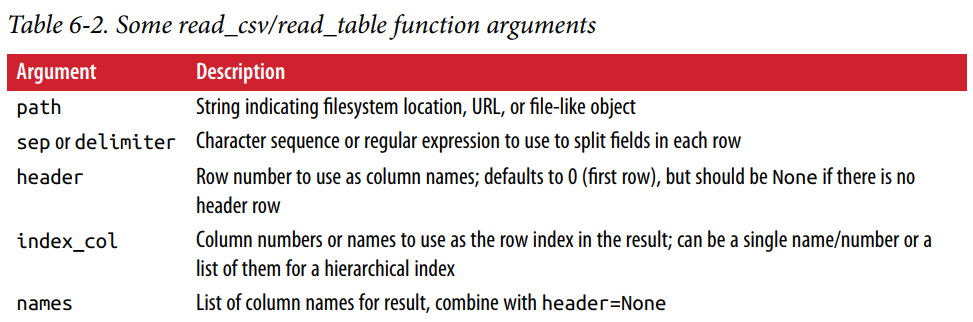

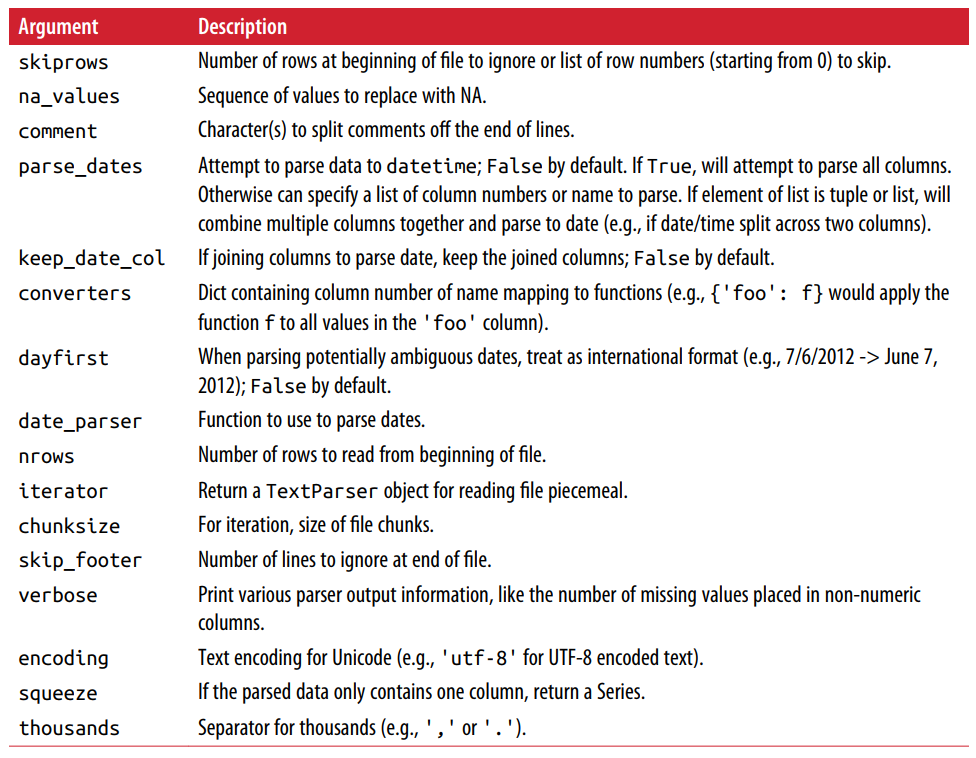

### 1. Reading Text Files in Pieces

When processing very large files or figuring out the right set of arguments to correctly process a large file, you may only want to read in a small piece of a file or iterate through smaller chunks of the file.  
Before we look at a large file, we make the pandas display settings more compact:

```python
pd.options.display.max_rows = 10
```

```python
result = pd.read_csv('../examples/ex6.csv')
result
```

|  | one | two | three | four | key |
| --- | --- | --- | --- | --- | --- |
| 0 | 0.467976 | -0.038649 | -0.295344 | -1.824726 | L |
| 1 | -0.358893 | 1.404453 | 0.704965 | -0.200638 | B |
| 2 | -0.501840 | 0.659254 | -0.421691 | -0.057688 | G |
| 3 | 0.204886 | 1.074134 | 1.388361 | -0.982404 | R |
| 4 | 0.354628 | -0.133116 | 0.283763 | -0.837063 | Q |
| ... | ... | ... | ... | ... | ... |
| 9995 | 2.311896 | -0.417070 | -1.409599 | -0.515821 | L |
| 9996 | -0.479893 | -0.650419 | 0.745152 | -0.646038 | E |
| 9997 | 0.523331 | 0.787112 | 0.486066 | 1.093156 | K |
| 9998 | -0.362559 | 0.598894 | -1.843201 | 0.887292 | G |
| 9999 | -0.096376 | -1.012999 | -0.657431 | -0.573315 | 0 |

10000 rows × 5 columns

#### If you want to only read a small number of rows (avoiding reading the entire file), specify that with `nrows`:

```python
pd.read_csv('../examples/ex6.csv', nrows=5)
```

|  | one | two | three | four | key |
| --- | --- | --- | --- | --- | --- |
| 0 | 0.467976 | -0.038649 | -0.295344 | -1.824726 | L |
| 1 | -0.358893 | 1.404453 | 0.704965 | -0.200638 | B |
| 2 | -0.501840 | 0.659254 | -0.421691 | -0.057688 | G |
| 3 | 0.204886 | 1.074134 | 1.388361 | -0.982404 | R |
| 4 | 0.354628 | -0.133116 | 0.283763 | -0.837063 | Q |

#### To read a file in pieces, specify a `chunksize` as a number of rows:

```python
chunker = pd.read_csv('../examples/ex6.csv', chunksize=1000)
chunker
```

```
<pandas.io.parsers.TextFileReader at 0x1d748848e88>
```

#### The `TextParser` object returned by `read_csv` allows you to iterate over the parts of the file according to the `chunksize`.

- For example, we can iterate over ex6.csv, aggregating the value counts in the 'key' column like so:
- `TextParser` is also equipped with a `get_chunk` method that enables you to read pieces of an arbitrary size.

```python
chunker = pd.read_csv('../examples/ex6.csv', chunksize=1000)
tot = pd.Series([])
for piece in chunker:
    tot = tot.add(piece['key'].value_counts(), fill_value=0)
tot = tot.sort_values(ascending=False)
tot[:10]
```

```
E    368.0
X    364.0
L    346.0
O    343.0
Q    340.0
M    338.0
J    337.0
F    335.0
K    334.0
H    330.0
dtype: float64
```

### 2. Writing Data to Text Format

Data can also be exported to a delimited format. Let’s consider one of the CSV files read before:

```python
data = pd.read_csv('../examples/ex5.csv')
data
```

|  | something | a | b | c | d | message |
| --- | --- | --- | --- | --- | --- | --- |
| 0 | one | 1 | 2 | 3.0 | 4 | NaN |
| 1 | two | 5 | 6 | NaN | 8 | world |
| 2 | three | 9 | 10 | 11.0 | 12 | foo |

Using DataFrame’s `to_csv` method, we can write the data out to a comma-separated file:

```python
data.to_csv('../examples/out.csv')
!cat ../examples/out.csv
```

```
,something,a,b,c,d,message
0,one,1,2,3.0,4,
1,two,5,6,,8,world
2,three,9,10,11.0,12,foo
```

Other delimiters can be used, of course (writing to `sys.stdout` so **it prints the text result to the console**):

```python
import sys
data.to_csv(sys.stdout, sep='|')
```

```
|something|a|b|c|d|message
0|one|1|2|3.0|4|
1|two|5|6||8|world
2|three|9|10|11.0|12|foo
```

Missing values appear as `empty` strings in the output. You might want to denote them by some other sentinel value:

```python
data.to_csv(sys.stdout, na_rep='NULL')
```

```
,something,a,b,c,d,message
0,one,1,2,3.0,4,NULL
1,two,5,6,NULL,8,world
2,three,9,10,11.0,12,foo
```

With no other options specified, both the row and column labels are written. Both of these can be disabled:

```python
data.to_csv(sys.stdout, index=False, header=False)
```

```
one,1,2,3.0,4,
two,5,6,,8,world
three,9,10,11.0,12,foo
```

You can also write only a subset of the columns, and in an order of your choosing:

```python
data.to_csv(sys.stdout, index=False, columns=['a', 'b', 'c'])
```

```
a,b,c
1,2,3.0
5,6,
9,10,11.0
```

Series also has a `to_csv` method:

```python
dates = pd.date_range('1/1/2000', periods=7)
ts = pd.Series(np.arange(7), index=dates)
ts.to_csv('../examples/tseries.csv')
!cat ../examples/tseries.csv
```

```
,0
2000-01-01,0
2000-01-02,1
2000-01-03,2
2000-01-04,3
2000-01-05,4
2000-01-06,5
2000-01-07,6
```

### 3. Working with Delimited Formats

It’s not uncommon to receive a file with one or more malformed lines that trip up `read_table`. To illustrate the basic tools, consider a small CSV file:

```python
!cat ../examples/ex7.csv
```

```
"a","b","c"
"1","2","3"
"1","2","3"
```

For any file with a single-character delimiter, you can use Python’s built-in `csv` module.

```python
import csv
f = open('../examples/ex7.csv')
reader = csv.reader(f)
for line in reader:
    print(line)
```

```
['a', 'b', 'c']
['1', '2', '3']
['1', '2', '3']
```

#### From there, it’s up to you to do the wrangling necessary to put the data in the form that you need it

- First, we read the file into a list of lines

```python
with open('../examples/ex7.csv') as f:
    lines = list(csv.reader(f))
    print(lines)
```

```
[['a', 'b', 'c'], ['1', '2', '3'], ['1', '2', '3']]
```

Then, we split the lines into the header line and the data lines:

```python
header, values = lines[0], lines[1:]
```

Then we can create a dictionary of data columns using a dictionary comprehension and the expression `zip(*values)`, which transposes rows to columns:

```python
data_dict = {h: v for h, v in zip(header, zip(*values))}
data_dict
```

```
{'a': ('1', '1'), 'b': ('2', '2'), 'c': ('3', '3')}
```

#### To define a new format with a different delimiter, string quoting convention, or line terminator, we define a simple subclass of `csv.Dialect`:

```python
with open('../examples/ex7.csv') as f:
    class my_dialect(csv.Dialect):
        lineterminator = '\n'
        delimiter = ';'
        quotechar = '"'
        quoting = csv.QUOTE_MINIMAL

    reader = csv.reader(f, dialect=my_dialect)
    print(list(reader))
```

```
[['a,"b","c"'], ['1,"2","3"'], ['1,"2","3"']]
```

To write delimited files manually, you can use `csv.writer`. It accepts an open, writable file object and the same dialect and format options as `csv.reader`:

```python
with open('mydata.csv', 'w') as f:
    writer = csv.writer(f, dialect=my_dialect)
    writer.writerow(('one', 'two', 'three'))
    writer.writerow(('1', '2', '3'))
    writer.writerow(('4', '5', '6'))
    writer.writerow(('7', '8', '9'))
```

The possible options (attributes of `csv.Dialect`) and what they do can be found in Table 6-3.

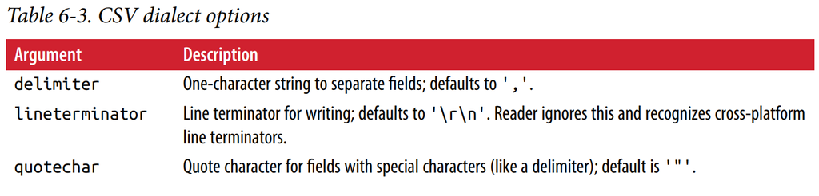

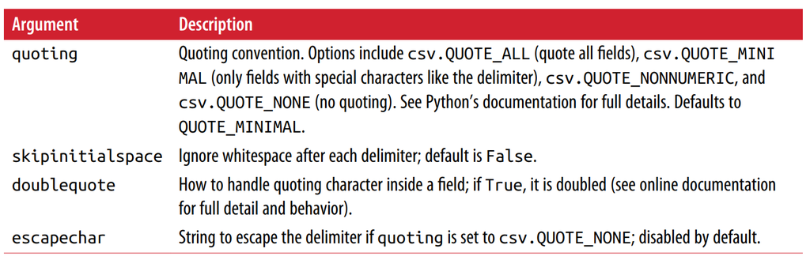

### 4. JSON Data

- SON (short for JavaScript Object Notation) has become one of the standard formats for sending data by HTTP request between web browsers and other applications.
- . It is a much **more free-form data format** than a tabular text form like CSV. Here is an example:

```python
obj = """
{"name": "Wes",
"places_lived": ["United States", "Spain", "Germany"],
"pet": null,
"siblings": [{"name": "Scott", "age": 30, "pets": ["Zeus", "Zuko"]},
{"name": "Katie", "age": 38,
"pets": ["Sixes", "Stache", "Cisco"]}]
}
"""
```

#### To convert a JSON string to Python form, use `json.loads`:

```python
import json
result = json.loads(obj)
result
```

```
{'name': 'Wes',
 'places_lived': ['United States', 'Spain', 'Germany'],
 'pet': None,
 'siblings': [{'name': 'Scott', 'age': 30, 'pets': ['Zeus', 'Zuko']},
  {'name': 'Katie', 'age': 38, 'pets': ['Sixes', 'Stache', 'Cisco']}]}
```

#### `json.dumps`, on the other hand, converts a Python object back to JSON:

```python
asjson = json.dumps(result)
```

Conveniently, you can pass a list of dicts (which were previously JSON objects) to the DataFrame constructor and select a sub‐set of the data fields:

```python
siblings = pd.DataFrame(result['siblings'], columns=['name', 'age'])
siblings
```

|  | name | age |
| --- | --- | --- |
| 0 | Scott | 30 |
| 1 | Katie | 38 |

**The `pandas.read_json` can automatically convert JSON datasets** in specific arrangements into a Series or DataFrame. For example:

```python
!cat ../examples/example.json
```

```
[{"a": 1, "b": 2, "c": 3},
 {"a": 4, "b": 5, "c": 6},
 {"a": 7, "b": 8, "c": 9}]
```

```python
data = pd.read_json('../examples/example.json')
data
```

|  | a | b | c |
| --- | --- | --- | --- |
| 0 | 1 | 2 | 3 |
| 1 | 4 | 5 | 6 |
| 2 | 7 | 8 | 9 |

If you need to **export data from pandas to JSON**, one way is to use the `to_json` methods on Series and DataFrame:

```python
print(data.to_json())
```

```
{"a":{"0":1,"1":4,"2":7},"b":{"0":2,"1":5,"2":8},"c":{"0":3,"1":6,"2":9}}
```

```python
print(data.to_json(orient='records'))
```

```
[{"a":1,"b":2,"c":3},{"a":4,"b":5,"c":6},{"a":7,"b":8,"c":9}]
```

### 5. XML and HTML: Web Scraping

Python has many libraries for reading and writing data in the ubiquitous HTML and XML formats.

- Examples include `lxml`, `Beautiful Soup`, and `html5lib`.
- While lxml is comparatively much faster in general, the other libraries can better handle malformed HTML or XML files.

```python
# conda install lxml
# pip install beautifulsoup4 html5lib
```

The `pandas.read_html` function has a number of options, but by default it **searches for and attempts to parse all tabular data contained within `<table>` tags**.

```python
tables = pd.read_html('../examples/fdic_failed_bank_list.html')
len(tables)
```

```
1
```

```python
failures = tables[0]
failures.head()
```

|  | Bank Name | City | ST | CERT | Acquiring Institution | Closing Date | Updated Date |
| --- | --- | --- | --- | --- | --- | --- | --- |
| 0 | Allied Bank | Mulberry | AR | 91 | Today's Bank | September 23, 2016 | November 17, 2016 |
| 1 | The Woodbury Banking Company | Woodbury | GA | 11297 | United Bank | August 19, 2016 | November 17, 2016 |
| 2 | First CornerStone Bank | King of Prussia | PA | 35312 | First-Citizens Bank & Trust Company | May 6, 2016 | September 6, 2016 |
| 3 | Trust Company Bank | Memphis | TN | 9956 | The Bank of Fayette County | April 29, 2016 | September 6, 2016 |
| 4 | North Milwaukee State Bank | Milwaukee | WI | 20364 | First-Citizens Bank & Trust Company | March 11, 2016 | June 16, 2016 |

```python
close_timestamps = pd.to_datetime(failures['Closing Date'])
close_timestamps.dt.year.value_counts()
```

```
2010    157
2009    140
2011     92
2012     51
2008     25
       ...
2004      4
2001      4
2007      3
2003      3
2000      2
Name: Closing Date, Length: 15, dtype: int64
```

#### 5.1 Parsing XML with `lxml.objectify`

- XML (eXtensible Markup Language) is another common structured data format supporting hierarchical, nested data with metadata.
- XML and HTML are structurally similar, but XML is more general. Here, I will show an example of how to use lxml to parse data from a more general XML format

Using `lxml.objectify`, we parse the file and get a reference to the root node of the XML file with getroot:

```python
from lxml import objectify
path = '../examples/Performance_MNR.xml'
parsed = objectify.parse(open(path))
root = parsed.getroot()
```

- `root.INDICATOR` returns a generator yielding each `<INDICATOR>` XML element
- For each record, we can populate a dict of tag names (like `YTD_ACTUAL`) to data values (excluding a few tags)

```python
data = []
skip_fields = ['PARENT_SEQ', 'INDICATOR_SEQ',
'DESIRED_CHANGE', 'DECIMAL_PLACES']

for elt in root.INDICATOR:
    el_data = {}
    for child in elt.getchildren():
        if child.tag in skip_fields:
            continue
        el_data[child.tag] = child.pyval
    data.append(el_data)
```

Lastly, convert this list of dicts into a DataFrame:

```python
perf = pd.DataFrame(data)
perf
```

|  | AGENCY_NAME | INDICATOR_NAME | DESCRIPTION | PERIOD_YEAR | PERIOD_MONTH | CATEGORY | FREQUENCY | INDICATOR_UNIT | YTD_TARGET | YTD_ACTUAL | MONTHLY_TARGET | MONTHLY_ACTUAL |
| --- | --- | --- | --- | --- | --- | --- | --- | --- | --- | --- | --- | --- |
| 0 | Metro-North Railroad | Escalator Availability | Percent of the time that escalators are operat... | 2011 | 12 | Service Indicators | M | % | 97.0 |  | 97.0 |  |

#### XML data can get much more complicated than this example.

- Each tag can have metadata, too. Consider an HTML link tag, which is also valid XML

```python
from io import StringIO
tag = '<a href="http://www.google.com">Google</a>'
root = objectify.parse(StringIO(tag)).getroot()
```

#### You can now access any of the fields (like href) in the tag or the link text

```python
root.get('href')
```

```
'http://www.google.com'
```

```python
root.text
```

```
'Google'
```